# LinearRegression

Guillem

11 March 2020

## Regresión Lineal Simple

Cálculos a mano de los coeficientes

```r
sal <- c(1.8, 2.2, 3.5, 4.0, 4.3, 5.0)
tension <- c(100, 98, 110, 110, 112, 120)
(media_sal <- mean(sal))
```

```
## [1] 3.466667
```

```r
(media_tension <- mean(tension))
```

```
## [1] 108.3333
```

```r
(var_sal <- var(sal))
```

```
## [1] 1.542667
```

```r
(cov_salten <- cov(sal, tension))
```

```
## [1] 9.773333
```

```r
(b1 <- cov_salten/var_sal)
```

```
## [1] 6.33535
```

```r
(b0 <- media_tension - b1*media_sal)
```

```
## [1] 86.37079
```

La recta de regresión será:
$$\hat{y} = 86.3707865 + 6.33535 · x$$

Ahora lo calculamos directamente

```r
lm(tension ~ sal)
```

```
##
## Call:
## lm(formula = tension ~ sal)
##
## Coefficients:
## (Intercept)          sal
##      86.371        6.335
```

Vamos a comprobar las propiedades que cumple la regresión por mínimos cuadrados

- La **recta de regresión** pasa por el vector medio $(\bar{x}, \bar{y})$

```r
(round(media_tension - b0 - b1*media_sal, 6))
```

```
## [1] 0
```

- La media de los valores estimados a partir de la **recta de regresión** es igual a la media de los observados $(y_i, \bar{y})$

```r
tension_estimada <- b0 + b1*sal
(mean(tension_estimada)-mean(tension))
```

```
## [1] 0
```

- La estimación de la varianza para los datos del ejemplo anterior es la siguiente:

```r
errores <- tension_estimada - tension
SSE <- sum(errores**2)
n = length(sal)
(estimacion_varianza <- SSE/(n-2))
```

```
## [1] 5.436474
```

Entonces tenemos qu eel valor aproximado o estimado de $\sigma_E ^2$ es 5.4364

Calulemos las variabilidades anteriores y el **coeficiente de determinación** par alos datos del ejemplo:

-**Variabilidad total**:

```r
(SST <- sum((tension - media_tension)^2))
```

```
## [1] 331.3333
```

- **Variabilidad de la regresión**

```r
(SSR = sum((tension_estimada - media_tension)^2))
```

```
## [1] 309.5874
```

- **Variabilidad del error:**

```r
(SSE <- sum((tension- tension_estimada)**2))
```

```
## [1] 21.74589
```

```r
(round(SST-SSR-SSE, 6)) # SST = SSR + SSE
```

```
## [1] 0
```

El coeficiente de determinación $R^2$ será:

```r
(R2 <- SSR/SST)
```

```
## [1] 0.9343685
```

Otra manera de calcularlo es:

```r
(R2 <- var(tension_estimada)/var(tension))
```

```
## [1] 0.9343685
```

Podemos concluir que la regresión explica un 93.44% de la variabilidad de los datos

De forma automática podemos ver el $R^2$

```r
summary(lm(tension ~ sal))$r.squared
```

```
## [1] 0.9343685
```

Comprobamos para los atos d enuestro ejemplo si los errores siguen una distribución normal usando el test de **Kolmogorov-Smirnov-Lilliefors**:

```r
library(nortest)
lillie.test(errores)
```

```
##
##  Lilliefors (Kolmogorov-Smirnov) normality test
##
## data:  errores
## D = 0.28034, p-value = 0.1468
```

Como el $p_value$ es grande, podemos concluir que no teenmos evidencias suficientes para rechazar que los errores siguen una distribución normal

Hallemos los intervalos de confianza para el 95% de confianza para los parámetros $\beta_1$ y $\beta_0$

```r
alpha <- 0.05
S <- sqrt(estimacion_varianza)
extremo_izb1 <- b1-qt(1-alpha/2, n-2)*S/(sd(sal)*sqrt(n-1))
extremo_derb1 <- b1+qt(1-alpha/2, n-2)*S/(sd(sal)*sqrt(n-1))
(c(extremo_izb1, extremo_derb1))
```

```
## [1] 4.004434 8.666266
```

```r
alpha <- 0.05
S <- sqrt(estimacion_varianza)
extremo_izb1 <- b0-qt(1-alpha/2, n-2)*S*sqrt(1/n+media_sal^2/((n-1)*var(sal)))
extremo_derb1 <- b0+qt(1-alpha/2, n-2)*S*sqrt(1/n+media_sal^2/((n-1)*var(sal)))
(c(extremo_izb1, extremo_derb1))
```

```
## [1] 77.86906 94.87251
```

En R ya existe una función que automatiza estos cálculos

```r
confint(lm(tension~sal), level = 0.95)
```

```
##                 2.5 %    97.5 %
## (Intercept) 77.869064 94.872509
## sal          4.004434  8.666266
```

Hallemos un intervalor de confianza par aun nivel de sal $x_0 = 4.5$ para los parámetros $\mu_{y|4.5}$ y $y_0$ al 95% de confianza:

- Intervalo de confianza para $\mu_{y|4.5}$

```r
alpha <- 0.05
x0 <- 4.5
y0_estimado <- b0 + b1*x0
extremo_izmux0 <- y0_estimado - qt(1-alpha/2, n-2)*S*sqrt(1/n+(x0-media_sal)^2/((n-1)*var(sal)))
extremo_dermux0 <-  y0_estimado + qt(1-alpha/2, n-2)*S*sqrt(1/n+(x0-media_sal)^2/((n-1)*var(sal)))
(c(extremo_izmux0, extremo_dermux0))
```

```
## [1] 111.3041 118.4556
```

- Intervalo de confianza para $\hat{y}$ para $x_0 = 4.5$

```r
extremo_izmux0 <- y0_estimado - qt(1-alpha/2, n-2)*S*sqrt(1+ 1/n+(x0-media_sal)^2/((n-1)*var(sal)))
extremo_dermux0 <-  y0_estimado + qt(1-alpha/2, n-2)*S*sqrt(1 + 1/n+(x0-media_sal)^2/((n-1)*var(sal)))
(c(extremo_izmux0, extremo_dermux0))
```

```
## [1] 107.4843 122.2754
```

Para hallar el intervalo de confianza para el parámetro $\mu_{y|x_0}$ al $100 · (1 - \alpha)%$ de confianza hay que usar la función **predict.lm** de la forma siguiente:

**newdata <- data.frame(x = x0)** **predict.lm(lm(y~x), newdata, interval = “confidence”, level = nivel.confianza)**

Para el parámetro $y_0$ hay que usar la misma función pero cambiando el parámetro interval al valor predicition:

**newdata <- data.frame(x = x0)** **predict.lm(lm(y~x), newdata, interval = “prediction”, level = nivel.confianza)**

Hallamos los intervalos de confianza para los parámetros $\mu_{Y|4.5}$ y $y_0$ al 95% de confianza:

```r
newdata <- data.frame(sal = 4.5)
predict.lm(lm(tension~sal), newdata, interval = "confidence", level = 0.95)
```

```
##        fit      lwr      upr
## 1 114.8799 111.3041 118.4556
```

```r
predict.lm(lm(tension~sal), newdata, interval = "prediction", level = 0.95)
```

```
##        fit      lwr      upr
## 1 114.8799 107.4843 122.2754
```

### Contrastes de hipotesis de B1

$$\left\{
\begin{array}{ll}
H_0: & \beta_1 = 0 \\\
H_1: & \beta_1 \neq 0
\end{array}
\right.$$

```r
(t0 <- b1/(S/sd(sal)*sqrt(n-1)))
```

```
## [1] 1.509256
```

```r
(p <- 2*pt(abs(t0), n-2, lower.tail = FALSE))
```

```
## [1] 0.2057377
```

Para realizar el contraste anterior se puede mirar el summary de lm

```r
summary(lm(tension ~ sal))
```

```
##
## Call:
## lm(formula = tension ~ sal)
##
## Residuals:
##      1      2      3      4      5      6
##  2.226 -2.309  1.455 -1.712 -1.613  1.952
##
## Coefficients:
##             Estimate Std. Error t value Pr(>|t|)
## (Intercept)  86.3708     3.0621  28.206  9.4e-06 ***
## sal           6.3354     0.8395   7.546  0.00165 **
## ---
## Signif. codes:  0 '***' 0.001 '**' 0.01 '*' 0.05 '.' 0.1 ' ' 1
##
## Residual standard error: 2.332 on 4 degrees of freedom
## Multiple R-squared:  0.9344, Adjusted R-squared:  0.918
## F-statistic: 56.95 on 1 and 4 DF,  p-value: 0.001652
```

### Regresión lineal múltiple

Vamos a calcular los parámetros $\beta$ de una regresión multiple con la fórmula matricial $\hat\beta = (X^t · X)^{-1} · (X^t · y)$

```r
X = matrix(c(1, 78, 48.2, 2.75, 29.5, 1, 69, 45.5, 2.15, 26.3, 1, 77, 46.3, 4.41, 32.2, 1, 88, 49, 5.52, 36.5, 1, 67, 43, 3.21, 27.2, 1, 80, 48, 4.32, 27.7, 1, 74, 48, 2.31, 28.3, 1, 94, 53, 4.3, 30.3, 1, 102, 58, 3.71, 28.7), nrow = 9, byrow = TRUE)

y = c(57.5, 52.8, 61.3, 67, 53.5, 62.7, 56.2, 68.5, 69.2)

(estimaciones <- solve(t(X)%*%X)%*%(t(X)%*%y))
```

```
##             [,1]
## [1,]  7.14753240
## [2,]  0.10009447
## [3,]  0.72641738
## [4,]  3.07583698
## [5,] -0.03004215
```

En conclusión la función lineal de regresión es: $\hat{y} = 7.1475 + 0.100x_1 + 0.7264x_2 + 3.0758x_3 - 0.030x_4$

Automáticamente podemos calcularlo con lm

```r
lm(y ~ X[,2]+X[,3]+X[,4]+X[,5])
```

```
##
## Call:
## lm(formula = y ~ X[, 2] + X[, 3] + X[, 4] + X[, 5])
##
## Coefficients:
## (Intercept)       X[, 2]       X[, 3]       X[, 4]       X[, 5]
##     7.14753      0.10009      0.72642      3.07584     -0.03004
```

```r
summary(lm(y ~ X[,2]+X[,3]+X[,4]+X[,5]))
```

```
##
## Call:
## lm(formula = y ~ X[, 2] + X[, 3] + X[, 4] + X[, 5])
##
## Residuals:
##        1        2        3        4        5        6        7        8
## -0.04053 -0.12898  0.21498 -0.43238 -0.64610  0.22143  0.52245  1.12764
##        9
## -0.83852
##
## Coefficients:
##             Estimate Std. Error t value Pr(>|t|)
## (Intercept)  7.14753   16.45961   0.434   0.6865
## X[, 2]       0.10009    0.33971   0.295   0.7829
## X[, 3]       0.72642    0.78590   0.924   0.4076
## X[, 4]       3.07584    1.05918   2.904   0.0439 *
## X[, 5]      -0.03004    0.16646  -0.180   0.8656
## ---
## Signif. codes:  0 '***' 0.001 '**' 0.01 '*' 0.05 '.' 0.1 ' ' 1
##
## Residual standard error: 0.861 on 4 degrees of freedom
## Multiple R-squared:  0.9908, Adjusted R-squared:  0.9815
## F-statistic: 107.3 on 4 and 4 DF,  p-value: 0.0002541
```

Verifiquemos las propiedades de la regresión lineal:

- La función de regresión pasa por el medio $(\bar{x}_1, \bar{x}_2, ... , \bar{x}_k, \bar{y})$

```r
valores_medios <- apply(X[,1:5], 2, mean)
round(mean(y) - t(estimaciones)%*%valores_medios, 6)
```

```
##      [,1]
## [1,]    0
```

- La media de los valores estimados es igual a la media de los observados:

```r
valores_estimados <- X%*%estimaciones
round(mean(y) - mean(valores_estimados), 6)
```

```
## [1] 0
```

- Los errores $(e_i)_{i = 1, .., n}$ tienen media 0 y varianza $\tilde{S}_e^2 = \frac{SS_E}{n-1}$

```r
errores <- y - valores_estimados
round(mean(errores))
```

```
## [1] 0
```

```r
SSE <- sum(errores ^ 2)
n <- dim(X)[1]
var(errores) - SSE/(n-1)
```

```
##      [,1]
## [1,]    0
```

Calculemos ahora las variabilidades y el coeficiente de determinación para los datos del ejemplo trabajado:

- Variabilidad total:

```r
(SST <- sum((y - mean(y))^2))
```

```
## [1] 321.24
```

- Variabilidad de la regresión:

```r
(SSR <- sum((valores_estimados - mean(y))^2))
```

```
## [1] 318.2744
```

- Variabilidad de los errores:

```r
(SSE <- sum((valores_estimados - y)^2))
```

```
## [1] 2.965581
```

Ahora comprobamos que la **variabilidad total** se descompone d ela suma de la **variabilidad de la regresión** y la **variabilidad del error**:

```r
round(SST - SSR - SSE, 6)
```

```
## [1] 0
```

El coeficiente de determinación será:

```r
(R2 <- SSR/SST)
```

```
## [1] 0.9907683
```

```r
(R2 <- var(valores_estimados)/var(y))
```

```
##           [,1]
## [1,] 0.9907683
```

```r
summary(lm(y ~ X[,2]+X[,3]+X[,4]+X[,5]))$r.squared
```

```
## [1] 0.9907683
```

Calculemos ahora el **coeficiente de determinación ajustado**

```r
k <- dim(X)[2]-1
(R2_adj <- 1 - (1 - R2)*(n-1)/(n-k-1))
```

```
##           [,1]
## [1,] 0.9815367
```

```r
summary(lm(y ~ X[,2]+X[,3]+X[,4]+X[,5]))$adj.r.squared
```

```
## [1] 0.9815367
```

```r
(summary(lm(y ~ X[,2]))$adj.r.squared)
```

```
## [1] 0.8822663
```

```r
(summary(lm(y ~ X[,2]+X[,3]))$adj.r.squared)
```

```
## [1] 0.9617198
```

```r
(summary(lm(y ~ X[,2]+X[,3]+X[,4]))$adj.r.squared)
```

```
## [1] 0.9851091
```

```r
(summary(lm(y ~ X[,2]+X[,3]+X[,4]+X[,5]))$adj.r.squared)
```

```
## [1] 0.9815367
```

Observamos que la mejor $R_{adj}^2$ se consigue con los coeficientes $\beta_1$, $\beta_2$ y $\beta_3$, por lo que el modelo óptimo solo utilizaria estos coeficientes

También podemos usar el método de AIC (Akaike’s information criterion)

```r
(AIC(lm(y~X[,2]+X[,3]+X[,4]+X[,5])))
```

```
## [1] 27.54953
```

```r
(AIC(lm(y~X[,2]+X[,3]+X[,4])))
```

```
## [1] 25.62252
```

```r
(AIC(lm(y~X[,2]+X[,3])))
```

```
## [1] 33.76103
```

```r
(AIC(lm(y~X[,2])))
```

```
## [1] 43.25982
```

Escogemos el modelo que tenga un AIC más bajo por tanto la conclusión es la misma que con el R cuadrado ajustado ($R_{adj}^2$).

Una forma similar a AIC es aplicar el método BIC (Bayessian information criterion):

```r
(BIC(lm(y~X[,2]+X[,3]+X[,4]+X[,5])))
```

```
## [1] 28.73288
```

```r
(BIC(lm(y~X[,2]+X[,3]+X[,4])))
```

```
## [1] 26.60864
```

```r
(BIC(lm(y~X[,2]+X[,3])))
```

```
## [1] 34.54993
```

```r
(BIC(lm(y~X[,2])))
```

```
## [1] 43.85149
```

Al igual que con AIC escogemos el BIC más bajo por tanto la conclusión es la misma que tenemos con AIC y R cuadrado ajustado ($R_{adj}^2$)

Veamos si los errores de los datos del ejmplo se distribuyen normalmente usando el test de **Kolmogorov-Smirnov-Lilliefors**

```r
lillie.test(errores)
```

```
##
##  Lilliefors (Kolmogorov-Smirnov) normality test
##
## data:  errores
## D = 0.13583, p-value = 0.9029
```

Como el $p_{value}$ es muy grande, concluimos que no hay evidencias suficientes para rechazar que los errores se distribuyen en una normal

La estimación de la varianza común $S^2$ será:

```r
(S2 <- SSE/(n-k-1))
```

```
## [1] 0.7413952
```

La estimación de la matriz de covarianzas de los estimadores $b_1, b_2, b_3, b_4$ es la siguiente:

```r
S2*solve(t(X)%*%X)
```

```
##            [,1]        [,2]         [,3]          [,4]         [,5]
## [1,] 270.918803  5.32456268 -12.52087701 -13.743054914 -1.399872458
## [2,]   5.324563  0.11540219  -0.26585498  -0.325517882 -0.017626546
## [3,] -12.520877 -0.26585498   0.61764126   0.742417814  0.041580221
## [4,] -13.743055 -0.32551788   0.74241781   1.121859593 -0.005975861
## [5,]  -1.399872 -0.01762655   0.04158022  -0.005975861  0.027709704
```

En la matriz anterior, podemos observar que el estimador con más varianza sería $b_0$ seguido de $b_3$.

Las estimaciones de los errores estándar de los estimadores son:

```r
(errores_estandar <- sqrt(S2*diag(solve(t(X)%*%X))))
```

```
## [1] 16.4596113  0.3397090  0.7859016  1.0591787  0.1664623
```

- Intervalo de confianza para $b_0$ al 95% de confianza:

```r
alpha = 0.05
c(estimaciones[1] - qt(1-alpha/2, n-k-1)*errores_estandar[1],
  estimaciones[1] + qt(1-alpha/2, n-k-1)*errores_estandar[1])
```

```
## [1] -38.55167  52.84674
```

```r
alpha = 0.05
c(estimaciones[2] - qt(1-alpha/2, n-k-1)*errores_estandar[2],
  estimaciones[2] + qt(1-alpha/2, n-k-1)*errores_estandar[2])
```

```
## [1] -0.8430889  1.0432778
```

```r
alpha = 0.05
c(estimaciones[3] - qt(1-alpha/2, n-k-1)*errores_estandar[3],
  estimaciones[3] + qt(1-alpha/2, n-k-1)*errores_estandar[3])
```

```
## [1] -1.455595  2.908430
```

```r
alpha = 0.05
c(estimaciones[4] - qt(1-alpha/2, n-k-1)*errores_estandar[4],
  estimaciones[4] + qt(1-alpha/2, n-k-1)*errores_estandar[4])
```

```
## [1] 0.1350854 6.0165886
```

```r
alpha = 0.05
c(estimaciones[5] - qt(1-alpha/2, n-k-1)*errores_estandar[5],
  estimaciones[5] + qt(1-alpha/2, n-k-1)*errores_estandar[5])
```

```
## [1] -0.4922156  0.4321313
```

Mucho más rápido se hace con confint de lm

```r
confint(lm(y~X[,2]+X[,3]+X[,4]+X[,5]), level = 0.95)
```

```
##                   2.5 %     97.5 %
## (Intercept) -38.5516748 52.8467396
## X[, 2]       -0.8430889  1.0432778
## X[, 3]       -1.4555952  2.9084299
## X[, 4]        0.1350854  6.0165886
## X[, 5]       -0.4922156  0.4321313
```

Hallemos un intervalo de confianza para los datos del ejemplo anterior x10 = 75, x20 = 50, x30 = 4 y x40 = 30, el inervalo de ocnfianza para le parámetro $\mu_{Y|x_10 = 75, x_20 = 50, x_30 = 4, x_40 = 30}$ al 95 % de confianza

```r
alpha = 0.05
x0 = c(1, 75, 50, 4, 30)
y0_estimado = sum(estimaciones*x0)
c(y0_estimado - qt(1-alpha/2, n-k-1)*sqrt(S2*(t(x0)%*%solve(t(X)%*%X)%*%x0)), y0_estimado + qt(1-alpha/2, n-k-1)*sqrt(S2*(t(x0)%*%solve(t(X)%*%X)%*%x0)))
```

```
## [1] 52.98730 71.76784
```

El intervalo de confianza para el parámetro $y_0$ al 95% de confianza es el siguiente:

```r
c(y0_estimado - qt(1-alpha/2, n-k-1)*sqrt(S2*(1+ t(x0)%*%solve(t(X)%*%X)%*%x0)), y0_estimado + qt(1-alpha/2, n-k-1)*sqrt(S2*(1+ t(x0)%*%solve(t(X)%*%X)%*%x0)))
```

```
## [1] 52.68777 72.06737
```

```r
newdata <- data.frame(x1 = 75, x2 = 50, x3 = 4, x4 = 30)
x1 <- X[, 2]
x2 <- X[, 3]
x3 <- X[, 4]
x4 <- X[, 5]
predict.lm(lm(y~x1+x2+x3+x4), newdata, interval = "confidence", level = 0.95)
```

```
##        fit     lwr      upr
## 1 62.37757 52.9873 71.76784
```

```r
predict.lm(lm(y~x1+x2+x3+x4), newdata, interval = "prediction", level = 0.95)
```

```
##        fit      lwr      upr
## 1 62.37757 52.68777 72.06737
```

### Contrastes de hipótesis para los parametros $\beta_i$

$$\left\{
\begin{array}{ll}
H_0: \mu_{Y|x_1} = · · · = \mu_{Y|x_n} \\
H_1: \exists i,j \text{tal que} \mu_{Y|x_i} \neq \mu_{Y|x_j}
\end{array}
\right.$$

```r
anova(lm(y~X[, 2:5]))
```

```
## Analysis of Variance Table
##
## Response: y
##           Df Sum Sq Mean Sq F value    Pr(>F)
## X[, 2:5]   4 318.27  79.569  107.32 0.0002541 ***
## Residuals  4   2.97   0.741
## ---
## Signif. codes:  0 '***' 0.001 '**' 0.01 '*' 0.05 '.' 0.1 ' ' 1
```

$$\left\{
\begin{array}{ll}
H_0: \beta_i = 0 \\
H_1: \beta_i \neq 0
\end{array}
\right.$$

```r
summary(lm(y~X[, 2:5]))
```

```
##
## Call:
## lm(formula = y ~ X[, 2:5])
##
## Residuals:
##        1        2        3        4        5        6        7        8
## -0.04053 -0.12898  0.21498 -0.43238 -0.64610  0.22143  0.52245  1.12764
##        9
## -0.83852
##
## Coefficients:
##             Estimate Std. Error t value Pr(>|t|)
## (Intercept)  7.14753   16.45961   0.434   0.6865
## X[, 2:5]1    0.10009    0.33971   0.295   0.7829
## X[, 2:5]2    0.72642    0.78590   0.924   0.4076
## X[, 2:5]3    3.07584    1.05918   2.904   0.0439 *
## X[, 2:5]4   -0.03004    0.16646  -0.180   0.8656
## ---
## Signif. codes:  0 '***' 0.001 '**' 0.01 '*' 0.05 '.' 0.1 ' ' 1
##
## Residual standard error: 0.861 on 4 degrees of freedom
## Multiple R-squared:  0.9908, Adjusted R-squared:  0.9815
## F-statistic: 107.3 on 4 and 4 DF,  p-value: 0.0002541
```

### Diagnósticos de regresión

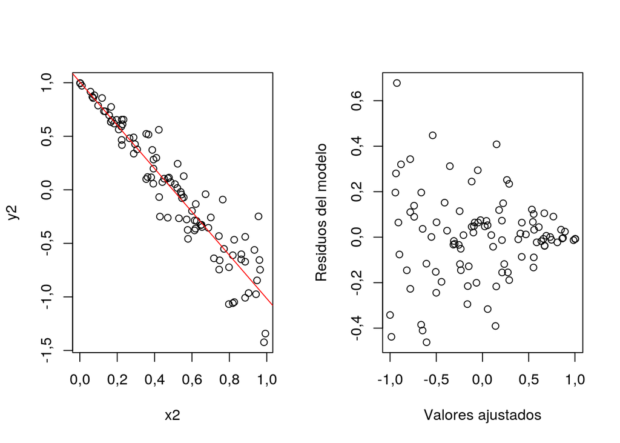

```r
set.seed(2020)
x2 <- runif(100)
y2 <- 1-2*x2+0.3*x2*rnorm(100)
par(mfrow=c(1,2))
plot(x2, y2)
r = lm(y2~x2)
abline(r, col = "red")
plot(r$res~r$fitted.values, xlab = "Valores ajustados", ylab = "Residuos del modelo")
```

Parece que los puntos si que se ajustan a una recta si vemos el plot de la regresión. No obstante si observamos el plot de los resiudos detectamos cierta heterocedasticidad, ya que se observa un distribución “triangular”, donde a medida que aumenta el valor disminuye la dispersión.

Apliquemos ahora el **test de White**

```r
residuos <- r$residuals
(X0 <- length(residuos)*summary(lm(residuos^2~x2+I(x2^2)))$r.squared)
```

```
## [1] 21,16502
```

```r
(pvalue <- pchisq(X0, 2, lower.tail = FALSE))
```

```
## [1] 2,535569e-05
```

Como tenemos un $p_{value}$ concluimos consecuentemente que tenemos evidencias suficientes apra rechazar que las varianzas de los residuos no son iguales **Heterocedasticidad**

Para el **Test de White** R ya tiene una función `bptest` del paquete lmtest

```r
library(lmtest)
bptest(r, ~x2 + I(x2**2))
```

```
##
##  studentized Breusch-Pagan test
##
## data:  r
## BP = 21,165, df = 2, p-value = 2,536e-05
```

En este caso se nos aplica un test de Breusch-Pagan ya que el número de variables independientes es mayor al número de muestras de la variable dependiente.

No obstante apliquemos el **Test de Breusch-Pagan** directamente

```r
(R2 <- summary(lm(errores**2 ~ X))$r.squared)
```

```
## [1] 0,617589
```

```r
(X0 <- n*R2)
```

```
## [1] 5,558301
```

```r
(pvalue <- pchisq(X0, k, lower.tail = FALSE))
```

```
## [1] 0,2346521
```

Concluimos que no tenemos indicios suficientes para rechazar la homocedasticidad de los errores.

```r
bptest(lm(y2~x2))
```

```
##
##  studentized Breusch-Pagan test
##
## data:  lm(y2 ~ x2)
## BP = 18,782, df = 1, p-value = 1,465e-05
```

```r
library(car)
```

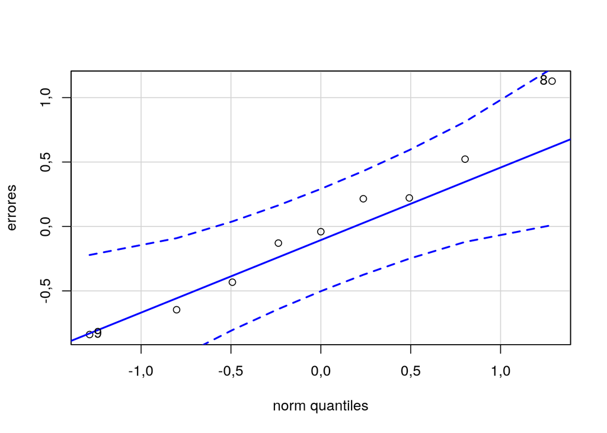

```
## [1] 8 9
```

```r
sigma_estimada <- sum(errores**2)/(n-k-1)
car::qqPlot(errores, distribution = "norm", mean = 0, sd = sqrt(sigma_estimada))
```

Para verificar que los residuos siguen una distribución normal aplicamos el **Kolmogorov-Smirnov-Lilliefors**

```r
lillie.test(errores)
```

```
##
##  Lilliefors (Kolmogorov-Smirnov) normality test
##
## data:  errores
## D = 0,13583, p-value = 0,9029
```

Como el p-value es muy grande, concluimos que no tenemos indicios suficentes para rechazar la normalidad de los residuos

### Autocorrelación de los errores

```r
diferencias <- errores[2:n] - errores[1:(n-1)]
(estadistico_d <- sum(diferencias**2)/sum(errores**2))
```

```
## [1] 1,910648
```

Si miramos los valores críticos para $\alpha = 0.05$, n = 9 y k = 4 en la Tabla del estadístico de Durbin-Watson, obtenemos los valores siguientes: $d_{L, 0.05} = 0.3$ y $d_{U, 0.05} = 2.59$

Como 1.91 está entre $d_{L, 0.05}$ y $d_{U, 0.05}$, estamos en la zona de penumbra y no podmeos tomar una decisión clara.

Si testeamos si hay autocorrelación negativa. El valor 4 - d será: 2.089352. Observamos también que 4 - esta entre $d_{L, 0.05}$ y $d_{U, 0.05}$, estamos en la zona de penumbra y no podemos tomar una decisión clara.

En resumen, en este ejemplo no podemos decidir d eforma clara a partir de Durbin-Watson sin los errores están correlados o incorrelados

```r
dwtest(r,alternative="greater")
```

```
##
##  Durbin-Watson test
##
## data:  r
## DW = 1,8812, p-value = 0,2739
## alternative hypothesis: true autocorrelation is greater than 0
```

```r
dwtest(r,alternative="less")
```

```
##
##  Durbin-Watson test
##
## data:  r
## DW = 1,8812, p-value = 0,7261
## alternative hypothesis: true autocorrelation is less than 0
```

### Contraste de Aditividad

```r
newr <- lm(y ~ X[,2]+X[,3]+X[,4]+X[,5])
valores_ajustados2 <- newr$fitted.values**2
summary(lm(y ~ X[,2]+X[,3]+X[,4]+X[,5]+valores_ajustados2))[[4]]
```

```
##                       Estimate  Std. Error    t value  Pr(>|t|)
## (Intercept)        -35,0865375 35,50436940 -0,9882315 0,3958971
## X[, 2]               0,4581385  0,41440666  1,1055288 0,3496254
## X[, 3]               1,9175739  1,15880577  1,6547846 0,1965424
## X[, 4]               8,8187502  4,47436401  1,9709505 0,1433141
## X[, 5]              -0,1208316  0,16793618 -0,7195092 0,5238131
## valores_ajustados2  -0,0167983  0,01277382 -1,3150568 0,2799764
```

Para realizar el **Test de Tuckey**:

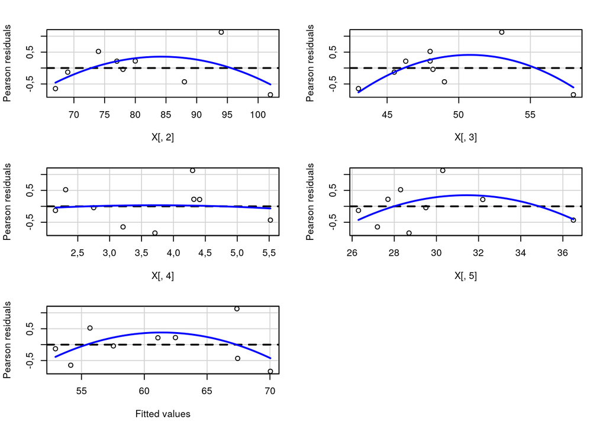

```
##            Test stat Pr(>|Test stat|)
## X[, 2]       -1,7307           0,1819
## X[, 3]       -2,2440           0,1105
## X[, 4]       -0,1425           0,8957
## X[, 5]       -1,0431           0,3736
## Tukey test   -1,3151           0,1885
```

```r
library(car)
car::residualPlots(newr, plot = TRUE)
```

Para observar la linealidad podemo graficar los residuos parciales $e_{ij} = e_i + b_i·x_{ij}$

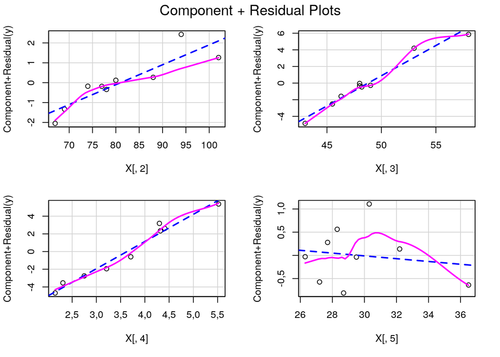

```r
library(car)
crPlots(newr)
```

La única variable que no se ajsuta al mdoelo lineal es la variable $x_4$. Todas las demás presentan un ajuste bastante aceptable

Vamos a calcular los leverages para la regresion realizada.

```r
(valores_hat <- hatvalues(newr))
```

```
##         1         2         3         4         5         6         7         8
## 0,4085728 0,3614889 0,3856998 0,7313416 0,5446839 0,7007824 0,6263533 0,5138878
##         9
## 0,7271895
```

```r
which(valores_hat > 2*(k+1)/n)
```

```
## named integer(0)
```

Vemos que nuestro ejemplo no hay ninguna observación que puede considerarse con **leverage** alto

Ahora buscamos si existe algún outlier en la muestra

```r
outlierTest(newr)
```

```
## No Studentized residuals with Bonferonni p < 0,05
## Largest |rstudent|:
##   rstudent unadjusted p-value Bonferonni p
## 8 4,736737            0,01784      0,16056
```

Observamos que la muestra 8 es que el que tiene el **residuo estunderizado** más alto pero el p-valor ajustado por Bonferroni nos permite rechazar que sea un **outlier**

Por último calcularemos la **distancia de Cook**

```r
(distancias_cook <- cooks.distance(newr))
```

```
##            1            2            3            4            5            6
## 0,0005175286 0,0039792364 0,0127433770 0,5110092593 0,2958675060 0,1035268247
##            7            8            9
## 0,3303469586 0,7459674243 1,8532516937
```

```r
(which(distancias_cook > 4/(n-k-1)))
```

```
## 9
## 9
```

Observamos que la muestra nº9 es una observación influyente según las **distancia de Cook**

### Selección de un modelo mejor

Existe la función `step` que, a partir del método AIC nos da el mejor modelo desde en el sentido de buscar un equilibrio entre la simplicidad y la adecuación:

```r
step(lm(y ~ X[,2]+X[,3]+X[,4]+X[,5]))
```

```
## Start:  AIC=0,01
## y ~ X[, 2] + X[, 3] + X[, 4] + X[, 5]
```

```
##          Df Sum of Sq    RSS     AIC
## - X[, 5]  1    0,0241 2,9897 -1,9184
## - X[, 2]  1    0,0644 3,0299 -1,7981
## - X[, 3]  1    0,6334 3,5990 -0,2491
## <none>                2,9656  0,0086
## - X[, 4]  1    6,2523 9,2179  8,2153
##
## Step:  AIC=-1,92
## y ~ X[, 2] + X[, 3] + X[, 4]
```

```
##          Df Sum of Sq    RSS     AIC
## - X[, 2]  1    0,0467 3,0364 -3,7790
## <none>                2,9897 -1,9184
## - X[, 3]  1    0,7948 3,7845 -1,7968
## - X[, 4]  1    6,2331 9,2228  6,2201
##
## Step:  AIC=-3,78
## y ~ X[, 3] + X[, 4]
```

```
##          Df Sum of Sq     RSS    AIC
## <none>                  3,036 -3,779
## - X[, 4]  1     102,9 105,939 26,191
## - X[, 3]  1     132,1 135,133 28,381
```

```
##
## Call:
## lm(formula = y ~ X[, 3] + X[, 4])
##
## Coefficients:
## (Intercept)       X[, 3]       X[, 4]
##      2,1833       0,9576       3,3253
```

Con un AIC de -3.78, R nos dice que el mejor modelo es considerar las variables regresoras $x_2$ y $x_3$